# National Taiwanese Sample: APT Conference Summary

Paul M. Garrett

13/10/2020

# STATE OF THE PANDEMIC

## FIGURE 1: CASES, DEATHS, AND KEY POLICY DECISIONS BY DATE.

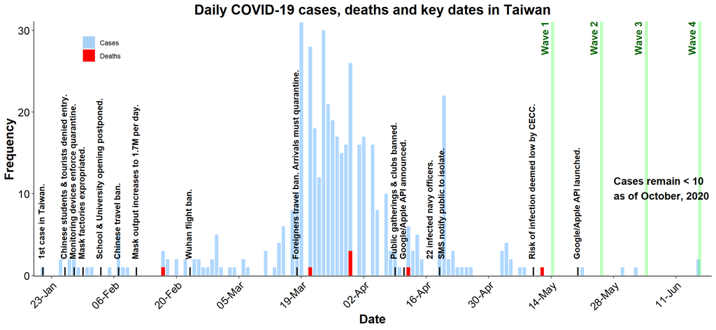

Figure 1. Key dates, cases, and deaths related to COVID-19 in Taiwan.

```r
#NOW = as.Date( Sys.time(), format = 'Y%-%m-%d')
NOW = as.Date('2020-06-18')
START = as.Date( '2020-01-19' )

TWN = WorldCOVIDdata('Taiwan',
                    StartDate = START, EndDate = NOW) %>%
  select(cases, deaths, date, country) %>%
  melt(id = c('date','country'))

# Allocated Data to dataframes for Key dates, Waves, and Taiwan Cases & Deaths.
Dates = data.frame( date = as.Date( c("2020-01-21", "2020-02-23",
                                      "2020-01-26", "2020-01-28",
                                      '2020-01-30', "2020-02-03",
                                      '2020-02-07', '2020-02-11',
                                      '2020-03-18', '2020-04-09',
                                      '2020-04-11', '2020-04-19',
                                      '2020-05-10', '2020-05-20'
                                      ),
                                    '%Y-%m-%d'),
                    text = c('1st case in Taiwan.', 'Wuhan flight ban.',
                             'Chinese students & tourists denied entry.',
                             'Monitoring devices enforce quarantine.',
                             'Mask factories expropriated.',
                             'School & University opening postponed.',
                             'Chinese travel ban.',
                             'Mask output increases to 1.7M per day.',
                             'Foreigners travel ban. Arrivals must quarantine.',
                             'Public gatherings & clubs banned.',
                             'Google/Apple API announced.',
                             '22 infected navy officers.\nSMS notify public to isolate.',
                             'Risk of infection deemed low by CECC.',
                             'Google/Apple API launched.'
                             ))

Waves = data.frame( start = as.Date( c("2020-05-14", "2020-05-25", "2020-06-04", "2020-06-16")),
                   text  = c('Wave 1','Wave 2','Wave 3', 'Wave 4'))

ft = 3.8
p  = 0
c  = 'sienna1'

# Plot Cases & Deaths in TWN
TWNPlot = ggplot(TWN) +
  geom_col(aes(date, value, group = variable, fill = variable), width = .8) + PltTheme +
  scale_fill_manual(values = alpha(c('dodgerblue','red'), c(.35,1)),
       labels = c('Cases','Deaths')) +
  scale_y_continuous( expand = c(0, .1), limits = c(0,max(TWN$value)) ) +
    scale_x_date(expand = c(0.0, 0), labels = date_format("%d-%b"), date_breaks = "14 days",
                 limits = c(START,  NOW+1)) +
    theme( legend.direction = 'vertical',
          legend.position = c(.1,.9),
          axis.text.x = element_text(angle=45, hjust = 1)) +
  labs(title = 'Daily COVID-19 cases, deaths and key dates in Taiwan', y = 'Frequency', x = 'Date')

# Add Data collectiond dates.
for (d in 1:nrow(Waves)){
  TWNPlot = TWNPlot +
  annotate("rect", xmin = Waves$start[d], xmax = Waves$start[d]+.7, ymin = 0, ymax = Inf, fill = 'green',  alpha = .25) +
  annotate("text", x = Waves$start[d], y = Inf, label = Waves$text[d], angle=90, color = 'darkgreen', size=4.5, vjust=-.4, hjust='right', fontface = "bold")
}

# Add key dates
for (d in 1:nrow(Dates)){
  TWNPlot = TWNPlot +
    annotate("text", x = Dates$date[d], y = p+2, label = Dates$text[d], angle=90, color = 'black', size=ft, vjust=0+.25, hjust='left', fontface = "bold") +
    geom_segment(x = Dates$date[d], y = 1+TWN$value[(TWN$date == Dates$date[d] & TWN$variable == 'deaths')], yend = p, xend = Dates$date[d], color = 'gray10', size = 1, alpha = 0.5 )
}

TWNPlot = TWNPlot + annotate("text", x = as.Date('2020-05-28'), y = 10, label = 'Cases remain < 10\nas of October, 2020',, color = 'black', size=ft+1, vjust=0+.25, hjust='left', fontface = "bold")

ggsave(plot = TWNPlot, filename = 'Figures//Cases.pdf', dpi = 5000, width = 13, height = 6)
TWNPlot
```

## Description of the data sample

```r
complyM = mean(W$COVID_comply_percent)
complySD = sd(W$COVID_comply_percent)
Phoneuse = Per(W$PhoneUse,1,2)
COVIDpos = Per(W$COVID_pos, 1, 2)
COVIDposOth = Per(W$COVID_pos_others, 1, 2)
LockdownM = mean(W$COVID_ndays_4)
LockdownSD = sd(W$COVID_ndays_4)
JobLost = Per(W$COVID_lost_job, 1, 2)
SocialDist = 'moderately' # Looked at the mean & median distribution of the likert responses.
GovSat_Policy = 'moderately' # Looked at the mean & median distribution of the likert responses.
GovSat_Govern = 'moderately' # Looked at the mean & median distribution of the likert responses.
GovSat_PubService = 'moderately' # Looked at the mean & median distribution of the likert responses.
TotalP = nrow(Data$Raw)
CleanP = nrow(W)
Wave1P = nrow(W %>% filter(WaveN == 'Wave 1'))
Wave2P = nrow(W %>% filter(WaveN == 'Wave 2'))
Wave3P = nrow(W %>% filter(WaveN == 'Wave 3'))
Wave4P = nrow(W %>% filter(WaveN == 'Wave 4'))
Removed = TotalP - CleanP
InitialWaveP = TotalP / 4
```

6000 nationally representative Taiwanese participants were sampled in four waves of 1500 space roughly one week apart between the dates of May 14th 2020 and June 16th 2020. Participants were exlcuded from analysis if they did not pass a scenario comprehension check. In total, 3825 participants passed the comprehension check (participants who passed comprehension checks in each wave were Wave 1 = 971, Wave 2 = 1018, Wave 3 = 939, Wave 4 = 897). In total, 2175 participants were removed from the analysis.

The following statistics and subsiquent analyses relate only to those participants who passed the attention checks:

- 99.69% of participants reported they used a mobile phone
- 2.61% of participants knew someone who had tested positive with COVID-19
- 0.44% of participants had tested positive with COVID-19
- Participants had spent a mean of 0.6224837 (SD = 3.05249) of the previous days in lockdown.
- 7.35% of participants had lost their job as a direct effect of COVID-19
- On average, particianpnts thought 59.2901961% (SD = 25.3928438) of the population were complying with COVID-19 policies
- Participants reported that they thought people were moderately complying with Social Distancing guidelines
- Participants were moderately satisfied with i) Government COVID-19 policies, ii) Governance during the pandemic, and iii) public services’ during the pandemic.

# Demographics: Figures and Tables

## Summary Figures

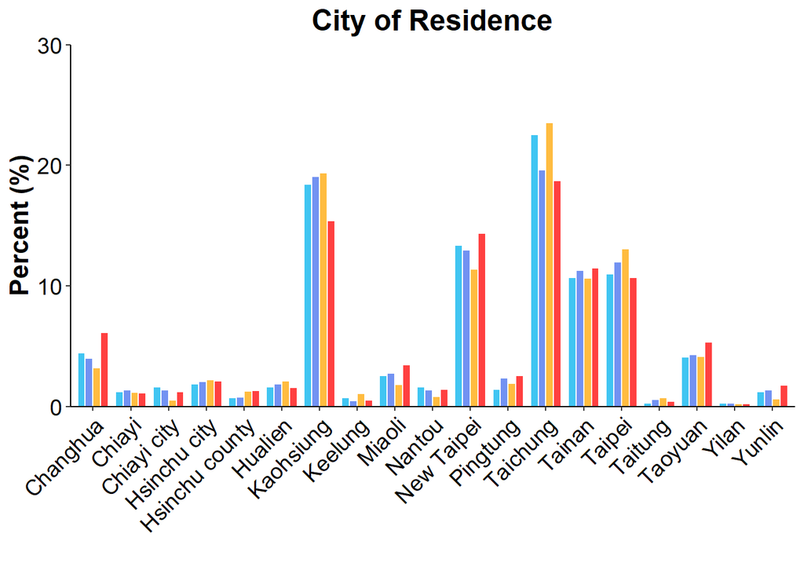

```r
ggplot(W) +
  geom_bar(aes(y = ..prop.., state, fill = WaveN, group = WaveN), position = 'dodge', color = 'white', size = .5, width = .82) + PltTheme +
  scale_fill_manual(values = WaveCols ) +
  scale_y_continuous( expand = c(0, 0), limits = c(0,.3), breaks = c(0, .1, .2, .3), labels = c('0','10','20','30') ) +
  theme( legend.position = 'none',
          axis.text.x = element_text(angle=45, hjust = 1)) +
  labs(title = 'City of Residence', y = 'Percent (%)', x = '')
```

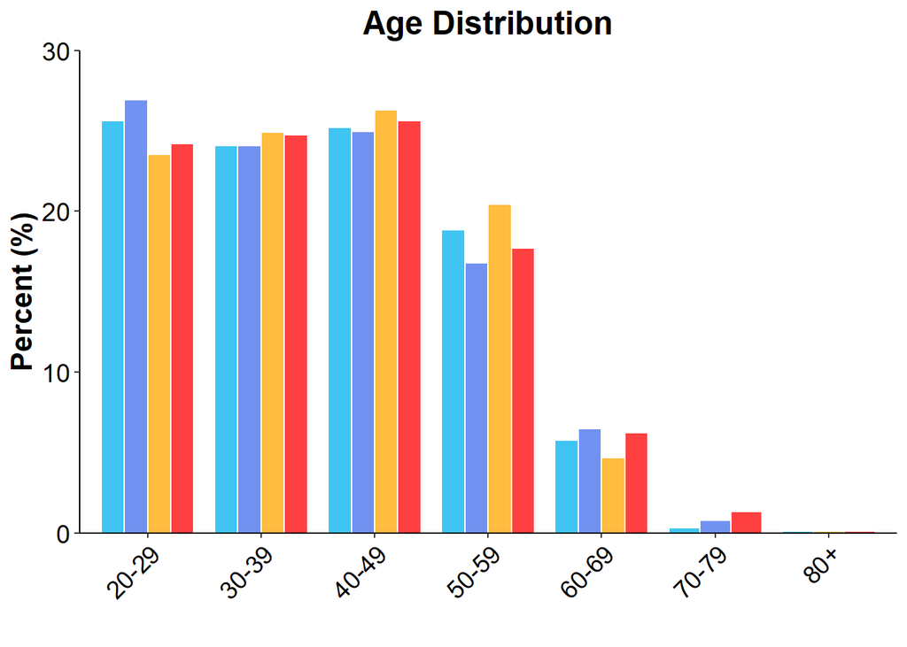

```r
ggplot(W) +
  geom_bar(aes(y = ..prop.., Agebins, fill = WaveN, group = WaveN), position = 'dodge', color = 'white', size = .5, width = .82) + PltTheme +
  scale_fill_manual(values = WaveCols ) +
  scale_y_continuous( expand = c(0, 0), limits = c(0,.3), breaks = c(0, .1, .2, .3), labels = c('0','10','20','30') ) +
  theme( legend.position = 'none',
          axis.text.x = element_text(angle=45, hjust = 1)) +
  labs(title = 'Age Distribution', y = 'Percent (%)', x = '')
```

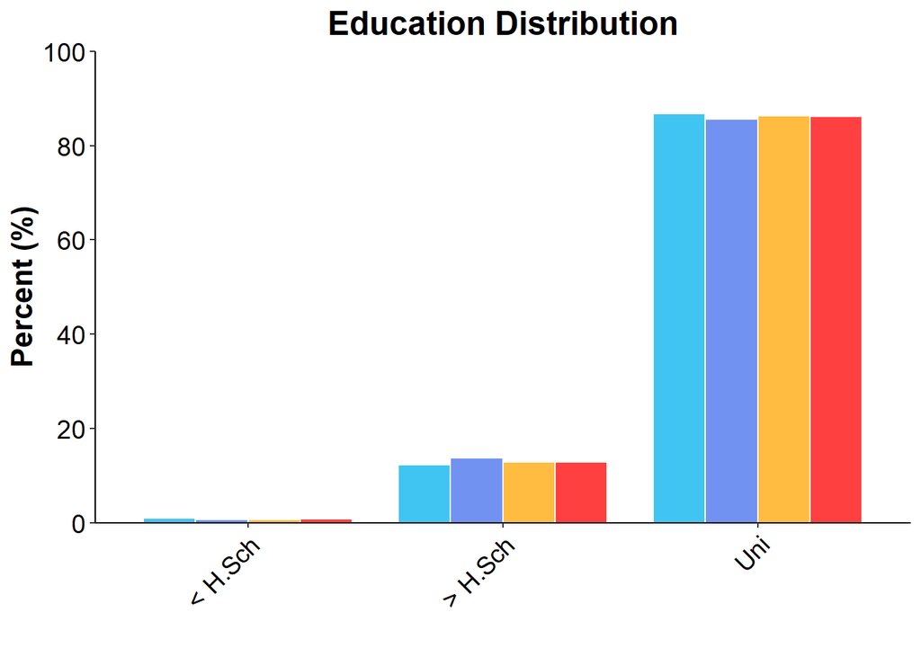

```r
ggplot(W) +
  geom_bar(aes(y = ..prop.., education, fill = WaveN, group = WaveN), position = 'dodge', color = 'white', size = .5, width = .82) + PltTheme +
  scale_fill_manual(values = WaveCols ) +
  scale_y_continuous( expand = c(0, 0), limits = c(0,1), breaks = c(0, .2, .4, .6, .8, 1), labels = c('0','20','40','60','80','100') ) +
  theme( legend.position = 'none',
          axis.text.x = element_text(angle=45, hjust = 1)) +
  labs(title = 'Education Distribution', y = 'Percent (%)', x = '')
```

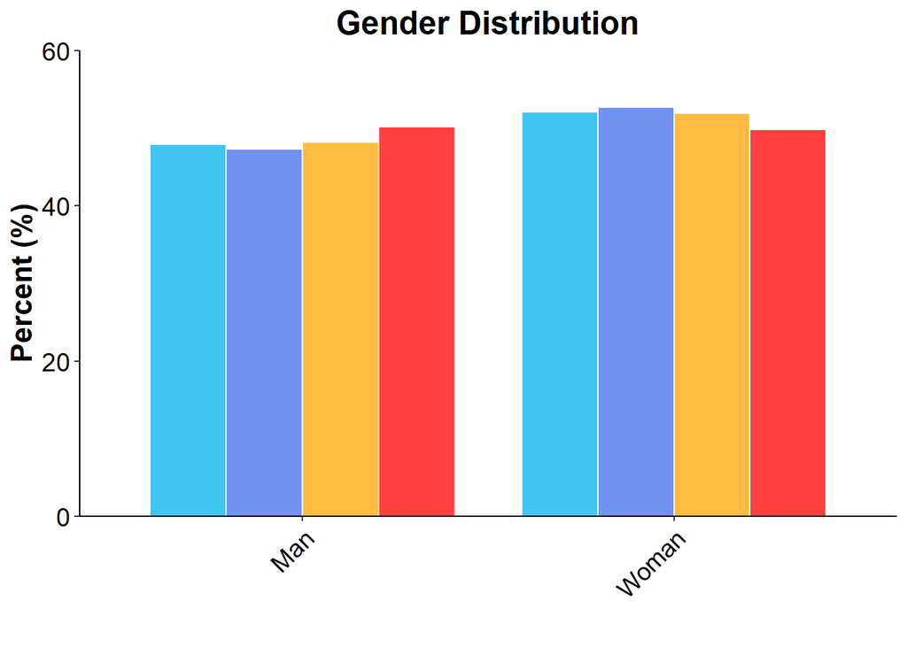

```r
ggplot(W) +
  geom_bar(aes(y = ..prop.., gender, fill = WaveN, group = WaveN), position = 'dodge', color = 'white', size = .5, width = .82) + PltTheme +
  scale_fill_manual(values = WaveCols ) +
  scale_y_continuous( expand = c(0, 0), limits = c(0,.6), breaks = c(0, .2, .4, .6), labels = c('0','20','40','60') ) +
  theme( legend.position = 'none',
          axis.text.x = element_text(angle=45, hjust = 1)) +
  labs(title = 'Gender Distribution', y = 'Percent (%)', x = '') +
  xlim(c('Man','Woman'))
```

## Descriptive Summary Tables

### Education

```r
cro_tpct(W$education, row_vars=W$WaveN) %>% set_caption("Level of education by wave: Percentages")  %>% rename(Percent = `#Total`)
```

| Level of education by wave: Percentages | Level of education by wave: Percentages | Level of education by wave: Percentages | Level of education by wave: Percentages Percent |
| --- | --- | --- | --- |
| W$WaveN |  |  |  |
| Wave 1 | W$education | < H.Sch | 1 |
|  |  | > H.Sch | 12.3 |
|  |  | Uni | 86.7 |
|  |  | #Total cases | 971 |
| Wave 2 | W$education | < H.Sch | 0.7 |
|  |  | > H.Sch | 13.8 |
|  |  | Uni | 85.6 |
|  |  | #Total cases | 1018 |
| Wave 3 | W$education | < H.Sch | 0.7 |
|  |  | > H.Sch | 12.9 |
|  |  | Uni | 86.4 |
|  |  | #Total cases | 939 |
| Wave 4 | W$education | < H.Sch | 0.9 |
|  |  | > H.Sch | 12.9 |
|  |  | Uni | 86.2 |
|  |  | #Total cases | 897 |

```r
cro_tpct(W$education) %>% set_caption("Level of education: Percentages")  %>% rename(Percent = `#Total`)
```

| Level of education: Percentages | Level of education: Percentages Percent |
| --- | --- |
| W$education |  |
| < H.Sch | 0.8 |
| > H.Sch | 13 |
| Uni | 86.2 |
| #Total cases | 3825 |

### Gender

```r
cro_tpct(W$gender, row_vars=W$WaveN) %>% set_caption("Gender by wave: Percentages")  %>% rename(Percent = `#Total`)
```

| Gender by wave: Percentages | Gender by wave: Percentages | Gender by wave: Percentages | Gender by wave: Percentages Percent |
| --- | --- | --- | --- |
| W$WaveN |  |  |  |
| Wave 1 | W$gender | Man | 47.9 |
|  |  | Woman | 52.1 |
|  |  | Other |  |
|  |  | Prefer not to say |  |
|  |  | #Total cases | 971 |
| Wave 2 | W$gender | Man | 47.2 |
|  |  | Woman | 52.6 |
|  |  | Other | 0.2 |
|  |  | Prefer not to say |  |
|  |  | #Total cases | 1018 |
| Wave 3 | W$gender | Man | 48 |
|  |  | Woman | 51.8 |
|  |  | Other | 0.1 |
|  |  | Prefer not to say | 0.1 |
|  |  | #Total cases | 939 |
| Wave 4 | W$gender | Man | 50.1 |
|  |  | Woman | 49.7 |
|  |  | Other |  |
|  |  | Prefer not to say | 0.2 |
|  |  | #Total cases | 897 |

```r
cro_tpct(W$gender) %>% set_caption("Gender: Percentages")  %>% rename(Percent = `#Total`)
```

| Gender: Percentages | Gender: Percentages Percent |
| --- | --- |
| W$gender |  |
| Man | 48.3 |
| Woman | 51.6 |
| Other | 0.1 |
| Prefer not to say | 0.1 |
| #Total cases | 3825 |

### City of residence

```r
cro_tpct(W$state, row_vars=W$WaveN) %>% set_caption("City by wave: Percentages")  %>% rename(Percent = `#Total`)
```

| City by wave: Percentages | City by wave: Percentages | City by wave: Percentages | City by wave: Percentages Percent |
| --- | --- | --- | --- |
| W$WaveN |  |  |  |
| Wave 1 | W$state | Changhua | 4.4 |
|  |  | Chiayi | 1.2 |
|  |  | Chiayi city | 1.6 |
|  |  | Hsinchu city | 1.9 |
|  |  | Hsinchu county | 0.7 |
|  |  | Hualien | 1.6 |
|  |  | Kaohsiung | 18.4 |
|  |  | Keelung | 0.7 |
|  |  | Miaoli | 2.6 |
|  |  | Nantou | 1.6 |
|  |  | New Taipei | 13.4 |
|  |  | Pingtung | 1.4 |
|  |  | Taichung | 22.6 |
|  |  | Tainan | 10.7 |
|  |  | Taipei | 11 |
|  |  | Taitung | 0.3 |
|  |  | Taoyuan | 4.1 |
|  |  | Yilan | 0.3 |
|  |  | Yunlin | 1.2 |
|  |  | #Total cases | 971 |
| Wave 2 | W$state | Changhua | 4 |
|  |  | Chiayi | 1.4 |
|  |  | Chiayi city | 1.4 |
|  |  | Hsinchu city | 2.1 |
|  |  | Hsinchu county | 0.8 |
|  |  | Hualien | 1.9 |
|  |  | Kaohsiung | 19.1 |
|  |  | Keelung | 0.5 |
|  |  | Miaoli | 2.8 |

[output cut: 51 more lines]

```r
cro_tpct(W$state) %>% set_caption("City: Percentages")  %>% rename(Percent = `#Total`)
```

| City: Percentages | City: Percentages Percent |
| --- | --- |
| W$state |  |
| Changhua | 4.4 |
| Chiayi | 1.2 |
| Chiayi city | 1.2 |
| Hsinchu city | 2.1 |
| Hsinchu county | 1 |
| Hualien | 1.8 |
| Kaohsiung | 18.1 |
| Keelung | 0.7 |
| Miaoli | 2.6 |
| Nantou | 1.3 |
| New Taipei | 13 |
| Pingtung | 2.1 |
| Taichung | 21.1 |
| Tainan | 11 |
| Taipei | 11.7 |
| Taitung | 0.5 |
| Taoyuan | 4.5 |
| Yilan | 0.3 |
| Yunlin | 1.3 |
| #Total cases | 3825 |

### Age Bins

```r
cro_tpct(W$Agebins, row_vars=W$WaveN) %>% set_caption("Age bins by wave: Percentages")  %>% rename(Percent = `#Total`)
```

| Age bins by wave: Percentages | Age bins by wave: Percentages | Age bins by wave: Percentages | Age bins by wave: Percentages Percent |
| --- | --- | --- | --- |
| W$WaveN |  |  |  |
| Wave 1 | W$Agebins | 20-29 | 25.6 |
|  |  | 30-39 | 24.1 |
|  |  | 40-49 | 25.2 |
|  |  | 50-59 | 18.8 |
|  |  | 60-69 | 5.8 |
|  |  | 70-79 | 0.3 |
|  |  | 80+ | 0.1 |
|  |  | #Total cases | 971 |
| Wave 2 | W$Agebins | 20-29 | 26.9 |
|  |  | 30-39 | 24.1 |
|  |  | 40-49 | 25 |
|  |  | 50-59 | 16.8 |
|  |  | 60-69 | 6.5 |
|  |  | 70-79 | 0.8 |
|  |  | 80+ |  |
|  |  | #Total cases | 1018 |
| Wave 3 | W$Agebins | 20-29 | 23.5 |
|  |  | 30-39 | 24.9 |
|  |  | 40-49 | 26.3 |
|  |  | 50-59 | 20.4 |
|  |  | 60-69 | 4.7 |
|  |  | 70-79 |  |
|  |  | 80+ | 0.1 |
|  |  | #Total cases | 939 |
| Wave 4 | W$Agebins | 20-29 | 24.2 |
|  |  | 30-39 | 24.7 |
|  |  | 40-49 | 25.6 |
|  |  | 50-59 | 17.7 |
|  |  | 60-69 | 6.2 |
|  |  | 70-79 | 1.3 |
|  |  | 80+ | 0.1 |
|  |  | #Total cases | 897 |

```r
cro_tpct(W$Agebins) %>% set_caption("Age bins: Percentages")  %>% rename(Percent = `#Total`)
```

| Age bins: Percentages | Age bins: Percentages Percent |
| --- | --- |
| W$Agebins |  |
| 20-29 | 25.1 |
| 30-39 | 24.4 |
| 40-49 | 25.5 |
| 50-59 | 18.4 |
| 60-69 | 5.8 |
| 70-79 | 0.6 |
| 80+ | 0.1 |
| #Total cases | 3825 |

### Information Sources about COVID-19

```r
cro_tpct(W$COVID_info_source, row_vars=W$WaveN) %>% set_caption("COVID Info Source by wave: Percentages")  %>% rename(Percent = `#Total`)
```

| COVID Info Source by wave: Percentages | COVID Info Source by wave: Percentages | COVID Info Source by wave: Percentages | COVID Info Source by wave: Percentages Percent |
| --- | --- | --- | --- |
| W$WaveN |  |  |  |
| Wave 1 | W$COVID_info_source | Friend/ Family | 1 |
|  |  | News | 60.7 |
|  |  | Other | 0.4 |
|  |  | Radio | 0.1 |
|  |  | S.Media | 12.8 |
|  |  | TV | 25 |
|  |  | #Total cases | 971 |
| Wave 2 | W$COVID_info_source | Friend/ Family | 1.8 |
|  |  | News | 65.3 |
|  |  | Other | 0.3 |
|  |  | Radio | 0.2 |
|  |  | S.Media | 10.7 |
|  |  | TV | 21.7 |
|  |  | #Total cases | 1018 |
| Wave 3 | W$COVID_info_source | Friend/ Family | 0.7 |
|  |  | News | 65.6 |
|  |  | Other | 0.1 |
|  |  | Radio |  |
|  |  | S.Media | 12.9 |
|  |  | TV | 20.7 |
|  |  | #Total cases | 939 |
| Wave 4 | W$COVID_info_source | Friend/ Family | 0.9 |
|  |  | News | 64.4 |
|  |  | Other | 0.4 |
|  |  | Radio | 0.1 |
|  |  | S.Media | 16.4 |
|  |  | TV | 17.7 |
|  |  | #Total cases | 897 |

```r
cro_tpct(W$COVID_info_source) %>% set_caption("COVID Info Source: Percentages")  %>% rename(Percent = `#Total`)
```

| COVID Info Source: Percentages | COVID Info Source: Percentages Percent |
| --- | --- |
| W$COVID_info_source |  |
| Friend/ Family | 1.1 |
| News | 64 |
| Other | 0.3 |
| Radio | 0.1 |
| S.Media | 13.1 |
| TV | 21.4 |
| #Total cases | 3825 |

# Figures for the national paper

## FIGURE: RISKS FROM COVID-19

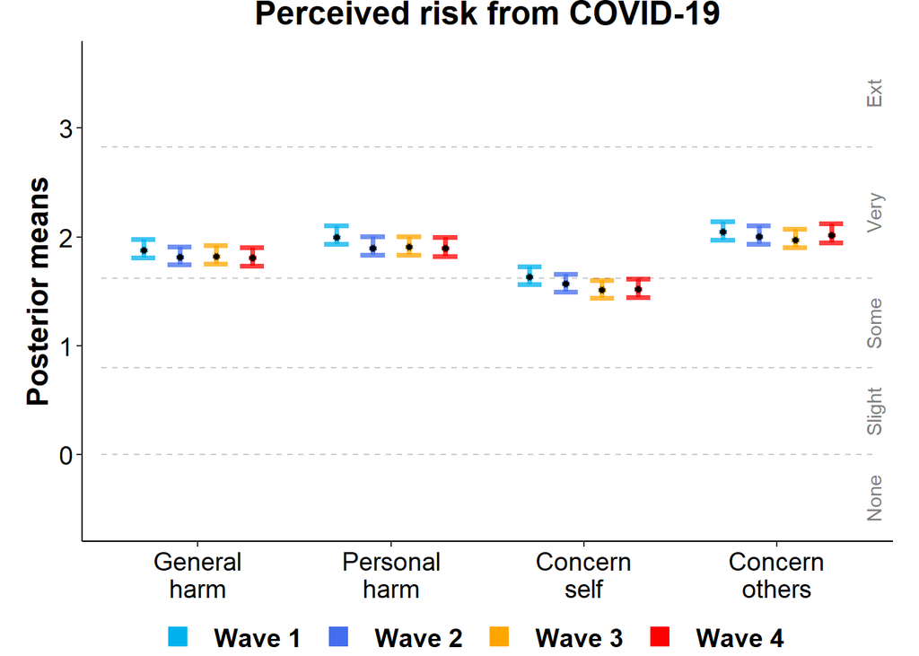

```r
Var = c('COVID_gen_harm','COVID_pers_harm','COVID_pers_concern','COVID_concern_oth')
CoVars = gather(W %>% select(WaveN, Var), key = 'key', value = 'value', Var, -WaveN )
CoVars$key = factor(CoVars$key,labels=c("General\nharm","Personal\nharm","Concern\nself","Concern\nothers"))

MCMCd_risk = MCMCpack::MCMCoprobit(as.formula('value ~ 1 + WaveN * key'), data = CoVars, tune = 0.3, mcmc = 20000)
MCMCs = HDIsummary(MCMCd_risk, levels(CoVars$WaveN), levels(CoVars$key))
Lines = Siglines(MCMCs)

tsize = 3.8
Plt = ggplot(MCMCs$Means, aes(x = Factor2, y = .value, group = Factor1, fill = Factor1, color = Factor1)) +
  geom_errorbar(aes(ymin = .lower, ymax = .upper, x = Factor2, group = Factor1),
                 position = position_dodge(.75), width = .5, size = 1.25, color = rep(WaveCols,each=4, alpha=1)) +
  geom_point(size = 2, shape = 21, stroke = 0, position = position_dodge(.75), alpha = 1) +
  PltTheme +
  scale_fill_manual(values = rep('black',4) ) + PltTheme +
  scale_color_manual(values = WaveCols, labels = c("Wave 1", "Wave 2", "Wave 3", "Wave 4") ) +
  ylab('Posterior means') + xlab('') +
  scale_y_continuous(expand = c(.0, .1), breaks = 0:5, limits = c(-.7, 3.7),
                     labels = c('0','1','2','3','4','5')) +
  theme( legend.direction = 'horizontal',
         legend.position = c(.47,-.19),
         plot.margin=unit(c(0,.5,0.4,.5),"cm"),
         legend.text=element_text(size=14, face = 'bold'),
         legend.key.size = unit(2,"line"),
         legend.key = element_rect(fill = "white")) +
  annotate('segment', x = 0.5, xend = 4.5, y = MCMCs$Cutpoints[1], yend = MCMCs$Cutpoints[1], alpha = .2, linetype = 'dashed') +
  annotate('segment', x = 0.5, xend = 4.5, y = MCMCs$Cutpoints[2], yend = MCMCs$Cutpoints[2], alpha = .2, linetype = 'dashed') +
  annotate('segment', x = 0.5, xend = 4.5, y = MCMCs$Cutpoints[3], yend = MCMCs$Cutpoints[3], alpha = .2, linetype = 'dashed') +
  annotate('segment', x = 0.5, xend = 4.5, y = MCMCs$Cutpoints[4], yend = MCMCs$Cutpoints[4], alpha = .2, linetype = 'dashed') +
  annotate('text', x = 4.5, y = MCMCs$Cutpoints[1] - MCMCs$Cutpoints[2]*.5, label = 'None', angle = 90, alpha = .5, size = tsize) +
  annotate('text', x = 4.5, y = MCMCs$Cutpoints[1] + MCMCs$Cutpoints[2]*.5, label = 'Slight', angle = 90, alpha = .5, size = tsize) +
  annotate('text', x = 4.5, y = MCMCs$Cutpoints[2] + (MCMCs$Cutpoints[3] - MCMCs$Cutpoints[2])*.5, label = 'Some', angle = 90, alpha = .5, size = tsize) +
  annotate('text', x = 4.5, y = MCMCs$Cutpoints[3] + (MCMCs$Cutpoints[4] - MCMCs$Cutpoints[3])*.5, label = 'Very', angle = 90, alpha = .5, size = tsize) +
  annotate('text', x = 4.5, y = MCMCs$Cutpoints[4] + (MCMCs$Cutpoints[4] - MCMCs$Cutpoints[3])*.4, label = 'Ext', angle = 90, alpha = .5, size = tsize) +
  labs(title = 'Perceived risk from COVID-19') +
  guides(colour = guide_legend(override.aes = list(shape = 15, size = 5)))

#for (ii in 1:length(Lines$y)){
#  Plt = Plt + annotate('segment', x = Lines$xi[ii], xend = Lines$xe[ii], y = Lines$y[ii], yend = Lines$y[ii] )
#}

ggsave(filename = 'Figures\\CovidRisks.pdf', plot = Plt, dpi = 5000, units = 'cm', height = 12.5, width = 18)
Plt
```

# FIGURE: BENEFITS FROM TRACKING

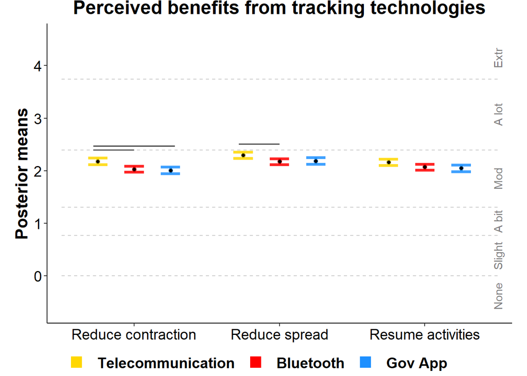

```r
Var = c('Reduce_Likelihood','Reduce_Spread','Return_Activity')
D = gather(W %>% select(Scenario, Var), key = 'key', value = 'value', Var, -Scenario )
D$key = factor(D$key,labels=c("Reduce contraction","Reduce spread", "Resume activities"))

MCMCd_benefits = MCMCpack::MCMCoprobit(as.formula('value ~ 1 + Scenario * key'), data = D, tune = 0.3, mcmc = 20000)
MCMCs = HDIsummary(MCMCd_benefits, levels(D$Scenario), levels(D$key))
Lines = Siglines(MCMCs, pos = c(-2, 0, 2), yoffset = .075 )

tsize = 3.8
Plt = ggplot(MCMCs$Means, aes(x = Factor2, y = .value, group = Factor1, fill = Factor1, color = Factor1)) +
  geom_errorbar(aes(ymin = .lower, ymax = .upper, x = Factor2, group = Factor1),
                 position = position_dodge(.75), width = .4, size = 1.25, color = rep(PrimeCols[c(1,2,3)],each=3, alpha=1)) +
  geom_point(size = 2, shape = 21, stroke = 0, position = position_dodge(.75), alpha = 1) +
  PltTheme +
  scale_fill_manual(values = rep('black',4), guide = FALSE ) + PltTheme +
  scale_color_manual(values = PrimeCols, labels = c("Telecommunication", "Bluetooth", "Gov App", "COVIDSafe") ) +
  ylab('Posterior means') + xlab('') +
  scale_y_continuous(expand = c(.0, .1), breaks = 0:5, limits = c(-.8, 4.7),
                     labels = c('0','1','2','3','4','5')) +
  theme( legend.direction = 'horizontal',
         legend.position = c(.44,-.13),
         plot.margin=unit(c(0,.5,0.5,.5),"cm"),
         legend.text=element_text(size=14, face = 'bold'),
         legend.key.size = unit(2,"line"),
         legend.key = element_rect(fill = "white")) +
  annotate('segment', x = 0.5, xend = 3.5, y = MCMCs$Cutpoints[1], yend = MCMCs$Cutpoints[1], alpha = .2, linetype = 'dashed') +
  annotate('segment', x = 0.5, xend = 3.5, y = MCMCs$Cutpoints[2], yend = MCMCs$Cutpoints[2], alpha = .2, linetype = 'dashed') +
  annotate('segment', x = 0.5, xend = 3.5, y = MCMCs$Cutpoints[3], yend = MCMCs$Cutpoints[3], alpha = .2, linetype = 'dashed') +
  annotate('segment', x = 0.5, xend = 3.5, y = MCMCs$Cutpoints[4], yend = MCMCs$Cutpoints[4], alpha = .2, linetype = 'dashed') +
  annotate('segment', x = 0.5, xend = 3.5, y = MCMCs$Cutpoints[5], yend = MCMCs$Cutpoints[5], alpha = .2, linetype = 'dashed') +
  annotate('text', x = 3.5, y = MCMCs$Cutpoints[1] - MCMCs$Cutpoints[2]*.5, label = 'None', angle = 90, alpha = .5, size = tsize) +
  annotate('text', x = 3.5, y = MCMCs$Cutpoints[1] + MCMCs$Cutpoints[2]*.5, label = 'Slight', angle = 90, alpha = .5, size = tsize) +
  annotate('text', x = 3.5, y = MCMCs$Cutpoints[2] + (MCMCs$Cutpoints[3] - MCMCs$Cutpoints[2])*.5, label = 'A bit', angle = 90, alpha = .5, size = tsize) +
    annotate('text', x = 3.5, y = MCMCs$Cutpoints[3] + (MCMCs$Cutpoints[4] - MCMCs$Cutpoints[3])*.5, label = 'Mod', angle = 90, alpha = .5, size = tsize) +
  annotate('text', x = 3.5, y = MCMCs$Cutpoints[4] + (MCMCs$Cutpoints[5] - MCMCs$Cutpoints[4])*.5, label = 'A lot', angle = 90, alpha = .5, size = tsize) +
  annotate('text', x = 3.5, y = MCMCs$Cutpoints[5] + (MCMCs$Cutpoints[5] - MCMCs$Cutpoints[4])*.3, label = 'Extr', angle = 90, alpha = .5, size = tsize) +
  labs(title = 'Perceived benefits from tracking technologies') +
  guides(colour = guide_legend(override.aes = list(shape = 15, size = 5)))

for (ii in 1:length(Lines$y)){
  Plt = Plt + annotate('segment', x = Lines$xi[ii], xend = Lines$xe[ii], y = Lines$y[ii], yend = Lines$y[ii] )
}

ggsave(filename = 'Figures\\TrackingBenefits.pdf', plot = Plt, dpi = 5000, units = 'cm', height = 12.5, width = 18)
Plt
```

# FIGURE: RISKS FROM TRACKING

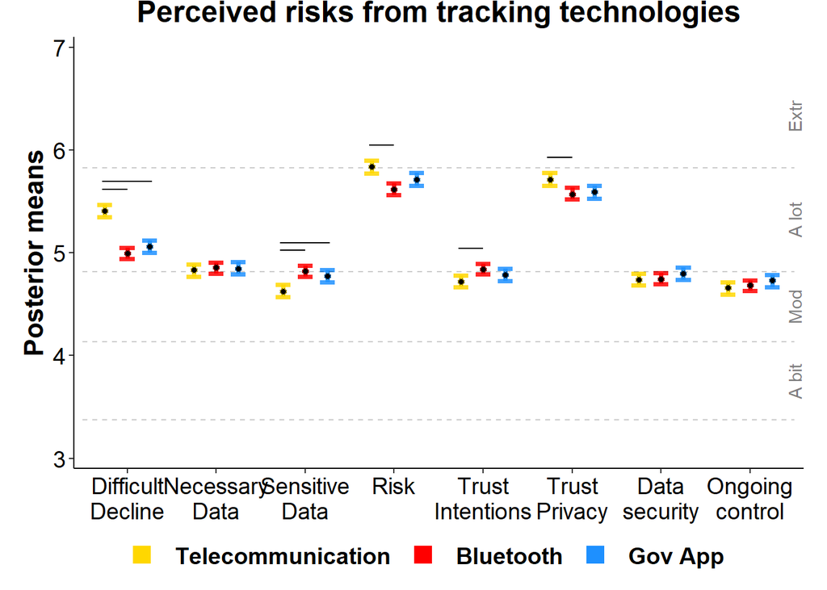

```r
Var = c('Decline', 'Necessary', 'Sensitive', 'Risk', 'TrustIntentions', 'TrustPrivacy', 'Security', 'ongoing_control')
D = gather(W %>% select(Scenario, Var), key = 'key', value = 'value', Var, -Scenario )
D$key = factor(D$key,labels=c('Difficult\nDecline','Necessary\nData','Sensitive\nData','Risk','Trust\nIntentions','Trust\nPrivacy','Data\nsecurity','Ongoing\ncontrol'))
D$key = factor(D$key, c('Difficult\nDecline','Necessary\nData','Sensitive\nData','Risk','Trust\nIntentions','Trust\nPrivacy','Data\nsecurity','Ongoing\ncontrol'))
#D$value[D$key == 'Difficult\nDecline'] = revscore(D$value[D$key == 'Difficult\nDecline'], 6)

MCMCd_percepts = MCMCpack::MCMCoprobit(as.formula('value ~ 1 + Scenario * key'), data = D, tune = 0.3, mcmc = 20000)
MCMCs = HDIsummary(MCMCd_percepts, levels(D$Scenario), levels(D$key))
Lines = Siglines(MCMCs, pos = c(-2, 0, 2), yoffset = .075)

tsize = 3.8
Plt = ggplot(MCMCs$Means, aes(x = Factor2, y = .value, group = Factor1, fill = Factor1, color = Factor1)) +
  geom_errorbar(aes(ymin = .lower, ymax = .upper, x = Factor2, group = Factor1),
                 position = position_dodge(.75), width = .5, size = 1.25, color = rep(PrimeCols[c(1,2,3)],each=8, alpha=1)) +
  geom_point(size = 2, shape = 21, stroke = 0, position = position_dodge(.75), alpha = 1) +
  PltTheme +
  scale_fill_manual(values = rep('black',4), guide = FALSE ) + PltTheme +
  scale_color_manual(values = PrimeCols, labels = c("Telecommunication", "Bluetooth", "Gov App", "COVIDSafe") ) +
  ylab('Posterior means') + xlab('') +
  scale_y_continuous(expand = c(.0, .1), breaks = 0:7, limits = c(3, 7),
                     labels = c('0','1','2','3','4','5','6','7')) +
  theme( legend.direction = 'horizontal',
         legend.position = c(.47,-.2),
         plot.margin=unit(c(0,.5,0.8,.5),"cm"),
         legend.text=element_text(size=14, face = 'bold'),
         legend.key.size = unit(2,"line"),
         legend.key = element_rect(fill = "white")) +
  annotate('segment', x = 0.5, xend = 8.5, y = MCMCs$Cutpoints[1], yend = MCMCs$Cutpoints[1], alpha = .2, linetype = 'dashed') +
  annotate('segment', x = 0.5, xend = 8.5, y = MCMCs$Cutpoints[2], yend = MCMCs$Cutpoints[2], alpha = .2, linetype = 'dashed') +
  annotate('segment', x = 0.5, xend = 8.5, y = MCMCs$Cutpoints[3], yend = MCMCs$Cutpoints[3], alpha = .2, linetype = 'dashed') +
  annotate('segment', x = 0.5, xend = 8.5, y = MCMCs$Cutpoints[4], yend = MCMCs$Cutpoints[4], alpha = .2, linetype = 'dashed') +
  annotate('segment', x = 0.5, xend = 8.5, y = MCMCs$Cutpoints[5], yend = MCMCs$Cutpoints[5], alpha = .2, linetype = 'dashed') +
  annotate('text', x = 8.5, y = MCMCs$Cutpoints[1] - MCMCs$Cutpoints[2]*.5, label = 'None', angle = 90, alpha = .5, size = tsize) +
  annotate('text', x = 8.5, y = MCMCs$Cutpoints[1] + MCMCs$Cutpoints[2]*.5, label = 'Slight', angle = 90, alpha = .5, size = tsize) +
  annotate('text', x = 8.5, y = MCMCs$Cutpoints[2] + (MCMCs$Cutpoints[3] - MCMCs$Cutpoints[2])*.5, label = 'A bit', angle = 90, alpha = .5, size = tsize) +
    annotate('text', x = 8.5, y = MCMCs$Cutpoints[3] + (MCMCs$Cutpoints[4] - MCMCs$Cutpoints[3])*.5, label = 'Mod', angle = 90, alpha = .5, size = tsize) +
  annotate('text', x = 8.5, y = MCMCs$Cutpoints[4] + (MCMCs$Cutpoints[5] - MCMCs$Cutpoints[4])*.5, label = 'A lot', angle = 90, alpha = .5, size = tsize) +
  annotate('text', x = 8.5, y = MCMCs$Cutpoints[5] + (MCMCs$Cutpoints[5] - MCMCs$Cutpoints[4])*.5, label = 'Extr', angle = 90, alpha = .5, size = tsize) +
  labs(title = 'Perceived risks from tracking technologies') +
  guides(colour = guide_legend(override.aes = list(shape = 15, size = 5)))

for (ii in 1:length(Lines$y)){
  Plt = Plt + annotate('segment', x = Lines$xi[ii], xend = Lines$xe[ii], y = Lines$y[ii], yend = Lines$y[ii] )
}

ggsave(filename = 'Figures\\TrackingRisks.pdf', plot = Plt, dpi = 5000, units = 'cm', height = 13, width = 22)
Plt
```

# FIGURE: ACCEPTABILITY OF TRACKING TECHNOLOGIES

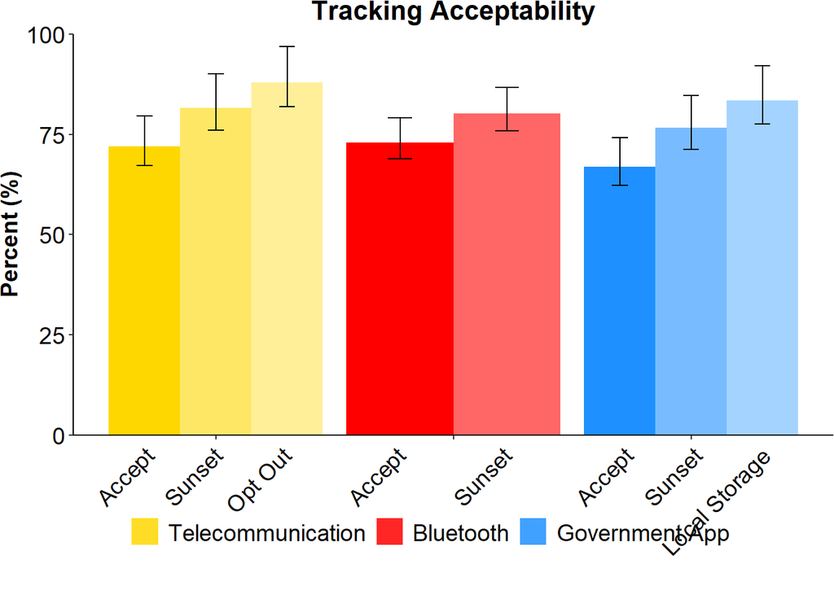

```r
D = W %>% select(Scenario, Accept2, Sunset, ChangeOther) %>% split(W$Scenario)
D$Telecommunication$ChangeOther = rowSums(cbind(D$Telecommunication$ChangeOther, D$Telecommunication$Accept2), na.rm=T)
D$`Government App`$ChangeOther = rowSums(cbind(D$`Government App`$ChangeOther, D$`Government App`$Accept2), na.rm=T)

CI = matrix(0, 9, 3)
count = 0
for (ii in 1:3){
  for (kk in 2:4){
    count = count + 1
    x = bayes.prop.test( as.integer(round(mean(D[[ii]][[kk]],na.rm=T) * 100)), nrow(D[[ii]]), n.iter = 20000 )
    CI[count,1] = x$stats[1,5] * 100
    CI[count,2] = x$stats[1,6] * 100
    CI[count,3] = mean(D[[ii]][[kk]],na.rm=T) * 100
  }
}

d = data.frame(Scenario = rep(levels(W$Scenario),each=3), key = c('Accept','Sunset','Opt Out', 'Accept', 'Sunset', 'NA','Accept', 'Sunset', 'Local Storage'), M = CI[,3], Low = CI[,1], High = CI[,2], color = c(1,.6,.4,1,.6,.4,1,.6,.4))
d = d[d$key != 'NA',]
d$Scenario = factor(d$Scenario, levels = c('Telecommunication', 'Bluetooth', 'Government App'))
d$key = factor(d$key, levels = c('Accept', 'Sunset', 'Opt Out', 'Local Storage'))
d$X   = c(.1, .19, .28, .43, .57, .73, .82, .91)


Plt = ggplot(d) +
  geom_col(aes(y = M, x = Scenario, group = key, fill = Scenario),  alpha = d$color,
           position = 'dodge') +
  geom_errorbar( aes(y = M, x = Scenario, group = key, fill = Scenario, ymin=M-Low, ymax=M+High), width=.2, position=position_dodge(.9)) +
  scale_fill_manual(values = PrimeCols ) +
  PltTheme +
  scale_y_continuous( expand = c(0, 0), limits = c(0,100) ) +
  labs(title = 'Tracking Acceptability', y = 'Percent (%)', x = '') +
  theme( legend.direction = 'vertical',
         plot.title = element_text(size = 16),
         axis.title = element_text(size=14),
         legend.key = element_rect(fill = "white"),
         legend.position = c(.5,-.23),
         legend.text = element_text(size = 14),
         #plot.margin=unit(c(0,0,1.7,0),"cm"),
         plot.margin=unit(c(0,0,2.5,0),"cm"),
         axis.text.x = element_text(angle=45, hjust = 1, color = 'white',size=0)) +
  guides(fill=guide_legend(ncol=4))

for (p in 1:8){
  Plt = Plt + annotation_custom(grob = textGrob(d$key[p], x = d$X[p], y = -.04, rot = 45, just = 1, gp = gpar(fontsize = 14) ))
}

gt <- ggplot_gtable(ggplot_build(Plt))
gt$layout$clip[gt$layout$name == "panel"] = "off"
#grid.arrange(gt)

ggsave(filename = 'Figures\\TrackingAcceptability.pdf', plot = gt, dpi = 5000, units = 'cm', height = 15, width = 24)

grid.arrange(gt)
```

# Modelling

## Examination of which items correlate with one-another

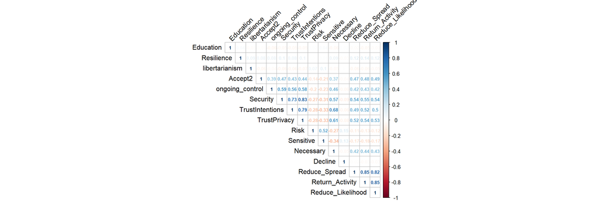

```r
CorData = W %>% select(Education, Resilience, libertarianism, Accept2, ongoing_control, Security, TrustIntentions, TrustPrivacy, Risk, Sensitive, Necessary, Decline, Reduce_Spread, Return_Activity, Reduce_Likelihood)

CorData %>%
  mutate(across(as.numeric())) %>%
  cor(use = "pairwise.complete.obs") %>%
  corrplot::corrplot(type = "upper", method = "number",
                     tl.col = "black", tl.srt = 45,
                     sig.level = 0.01, insig = "blank", number.cex = .70)
```

## Frequentist Modelling for Tracking Acceptance

```r
ModelData = W %>% select(Scenario, Age, education, gender, Resilience, libertarianism, Accept2, Sunset, ongoing_control, Security, TrustIntentions, TrustPrivacy, Risk, Sensitive, Necessary, Decline, Reduce_Spread, Return_Activity, Reduce_Likelihood)

### Check missing data
#nrow(ModelData)
#ModelData %>% drop_na() %>% nrow()

Equ = 'Accept2 ~ Age + education + gender + Resilience + libertarianism + ongoing_control + Security + TrustIntentions + TrustPrivacy + Risk + Sensitive + Necessary + Decline + Reduce_Spread + Return_Activity + Reduce_Likelihood + (1|Scenario)'

Model <- glmer(Equ, data = ModelData, family = binomial(link = "logit"),
                       control = glmerControl(optCtrl = list(maxfun=2e8)))
summary(Model)
```

```
## Generalized linear mixed model fit by maximum likelihood (Laplace
##   Approximation) [glmerMod]
##  Family: binomial  ( logit )
## Formula: Accept2 ~ Age + education + gender + Resilience + libertarianism +
##     ongoing_control + Security + TrustIntentions + TrustPrivacy +
##     Risk + Sensitive + Necessary + Decline + Reduce_Spread +
##     Return_Activity + Reduce_Likelihood + (1 | Scenario)
##    Data: ModelData
## Control: glmerControl(optCtrl = list(maxfun = 2e+08))
##
##      AIC      BIC   logLik deviance df.resid
##   3250.2   3381.4  -1604.1   3208.2     3804
##
## Scaled residuals:
##      Min       1Q   Median       3Q      Max
## -25.5831  -0.3359   0.2611   0.4903   7.7013
##
## Random effects:
##  Groups   Name        Variance Std.Dev.
##  Scenario (Intercept) 0.01193  0.1092
## Number of obs: 3825, groups:  Scenario, 3
##
## Fixed effects:
##                           Estimate Std. Error z value Pr(>|z|)
## (Intercept)             -6.5082887  0.7020246  -9.271  < 2e-16 ***
## Age                      0.0004474  0.0040579   0.110  0.91220
## education> H.Sch         1.4375455  0.4494683   3.198  0.00138 **
## educationUni             1.3459466  0.4348571   3.095  0.00197 **
## genderWoman             -0.0453171  0.0920121  -0.493  0.62236
## genderOther             -1.3653107  2.1610705  -0.632  0.52753
## genderPrefer not to say  0.4589739  1.5442879   0.297  0.76631
## Resilience               0.0066280  0.0032025   2.070  0.03849 *
## libertarianism          -0.0836711  0.0587116  -1.425  0.15412
## ongoing_control          0.2004871  0.0443216   4.523 6.08e-06 ***
## Security                 0.3662773  0.0672739   5.445 5.19e-08 ***
## TrustIntentions          0.1766553  0.0641416   2.754  0.00588 **
## TrustPrivacy             0.0651845  0.0702797   0.928  0.35367
## Risk                     0.1059795  0.0584247   1.814  0.06969 .
## Sensitive               -0.1942931  0.0602529  -3.225  0.00126 **
## Necessary                0.1131544  0.0525466   2.153  0.03129 *
## Decline                 -0.0177261  0.0445057  -0.398  0.69042
## Reduce_Spread            0.2245020  0.0826170   2.717  0.00658 **
## Return_Activity          0.2035556  0.0855548   2.379  0.01735 *
## Reduce_Likelihood        0.4796450  0.0791146   6.063 1.34e-09 ***
## ---
## Signif. codes:  0 '***' 0.001 '**' 0.01 '*' 0.05 '.' 0.1 ' ' 1
```